# Extra work on Project 2

waheeb Algabri

##### Load required packages

```r
library(tidyverse)
library(readr)
library(dplyr)
```

```r
songs <- read_csv("100 Songs.csv")
```

```r
head(songs)
```

```
## # A tibble: 6 × 14
##   id    name  durat…¹ energy   key loudn…²  mode speec…³ acous…⁴ instr…⁵ liven…⁶
##   <chr> <chr>   <dbl>  <dbl> <dbl>   <dbl> <dbl>   <dbl>   <dbl>   <dbl>   <dbl>
## 1 4ZtF… Good…    2.97  0.664     9   -5.04     1  0.154  0.335   0        0.0849
## 2 5fxy… Stay…    2.3   0.506     8  -11.3      1  0.0589 0.379   8.68e-1  0.11
## 3 5nuj… Levi…    3.38  0.825     6   -3.79     0  0.0601 0.00883 0        0.0674
## 4 4iJy… Peac…    3.3   0.696     0   -6.18     1  0.119  0.321   0        0.42
## 5 1SC5… Mont…    2.3   0.503     8   -6.72     0  0.22   0.293   0        0.405
## 6 3Dar… Kiss…    3.48  0.705     8   -3.46     1  0.0284 0.259   8.92e-5  0.12
## # … with 3 more variables: valence <dbl>, tempo <dbl>, danceability <dbl>, and
## #   abbreviated variable names ¹duration, ²loudness, ³speechiness,
## #   ⁴acousticness, ⁵instrumentalness, ⁶liveness
```

##### Tiding and transforming the data

```r
library(dplyr)
library(tidyr)

data <- songs %>%
  rename(
    Acousticness = acousticness,
    Danceability = danceability,
    Duration = duration,
    Energy = energy,
    Id = id,
    Instrumentalness = instrumentalness,
    Key = key,
    Liveness = liveness,
    Loudness = loudness,
    Mode = mode,
    Name = name,
    Speechiness = speechiness,
    Tempo = tempo,
    Valence = valence
  )
```

```r
sum(is.na(data))
```

```
## [1] 0
```

```r
sum(duplicated(data))
```

```
## [1] 10
```

Remove the duplicated

```r
data <- unique(data)
```

change the ID value to be NA

```r
data$ Id<- as.numeric(data$Id)
```

Replace the NA values in the Id column with numbers, you can use the if_else() function from dplyr package

```r
library(dplyr)

data <- data %>%
  mutate(Id = if_else(is.na(Id), 1:nrow(data), Id))
```

```r
knitr::kable(head(data), align = "c")
```

| Id | Name | Duration | Energy | Key | Loudness | Mode | Speechiness | Acousticness | Instrumentalness | Liveness | Valence | Tempo | Danceability |
| --- | --- | --- | --- | --- | --- | --- | --- | --- | --- | --- | --- | --- | --- |
| 1 | Good 4 U Olivia Rodrigo | 2.97 | 0.664 | 9 | -5.044 | 1 | 0.1540 | 0.33500 | 0.00e+00 | 0.0849 | 0.688 | 166.928 | 0.563 |
| 2 | Stay The Kid LAROI & Justin Bieber | 2.30 | 0.506 | 8 | -11.275 | 1 | 0.0589 | 0.37900 | 8.68e-01 | 0.1100 | 0.454 | 170.054 | 0.564 |
| 3 | Levitating Dua Lipa feat. DaBaby | 3.38 | 0.825 | 6 | -3.787 | 0 | 0.0601 | 0.00883 | 0.00e+00 | 0.0674 | 0.915 | 102.977 | 0.702 |
| 4 | Peaches Justin Bieber feat. Daniel Caesar & Giveon | 3.30 | 0.696 | 0 | -6.181 | 1 | 0.1190 | 0.32100 | 0.00e+00 | 0.4200 | 0.464 | 90.030 | 0.677 |
| 5 | Montero (Call Me By Your Name) Lil Nas X | 2.30 | 0.503 | 8 | -6.725 | 0 | 0.2200 | 0.29300 | 0.00e+00 | 0.4050 | 0.710 | 178.781 | 0.593 |
| 6 | Kiss Me More (feat. SZA) Doja Cat | 3.48 | 0.705 | 8 | -3.463 | 1 | 0.0284 | 0.25900 | 8.92e-05 | 0.1200 | 0.781 | 110.970 | 0.764 |

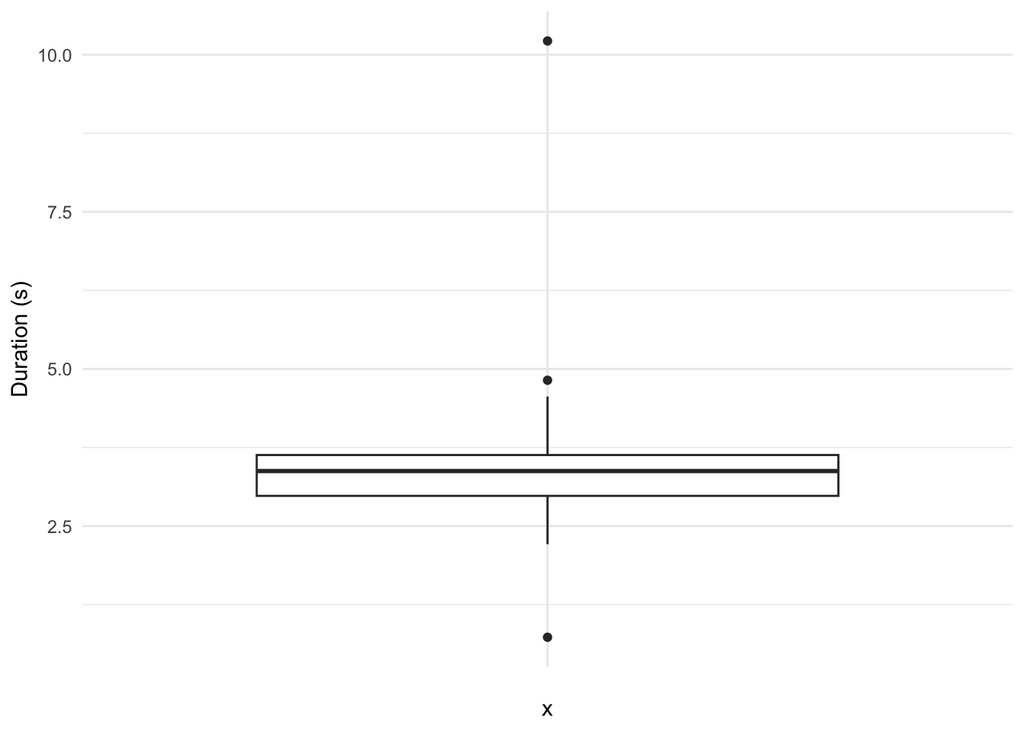

```r
library(ggplot2)

ggplot(data, aes(x = "", y = Duration)) +
 geom_boxplot() +
  labs(y = "Duration (s)") +
  theme_minimal()
```

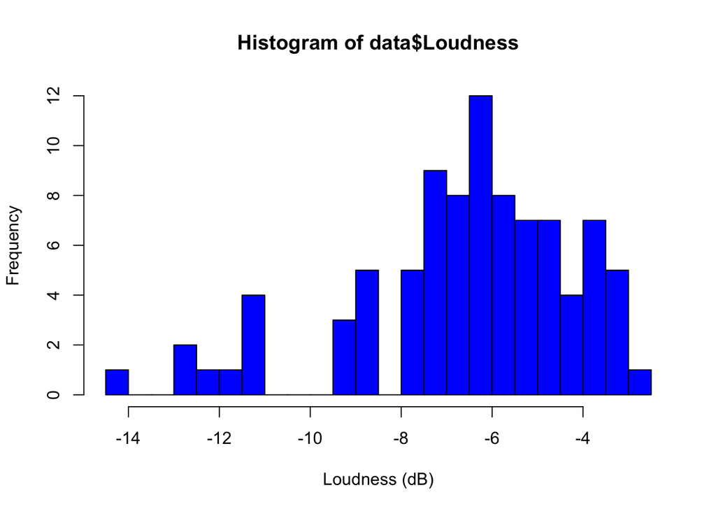

```r
hist(data$Loudness, breaks = 20, col = "blue", xlab = "Loudness (dB)")
```

```r
str(data)
```

```
## tibble [90 × 14] (S3: tbl_df/tbl/data.frame)
##  $ Id              : num [1:90] 1 2 3 4 5 6 7 8 9 10 ...
##  $ Name            : chr [1:90] "Good 4 U Olivia Rodrigo" "Stay The Kid LAROI & Justin Bieber" "Levitating Dua Lipa feat. DaBaby" "Peaches Justin Bieber feat. Daniel Caesar & Giveon" ...
##  $ Duration        : num [1:90] 2.97 2.3 3.38 3.3 2.3 3.48 4.03 4.03 3.33 3.59 ...
##  $ Energy          : num [1:90] 0.664 0.506 0.825 0.696 0.503 0.705 0.616 0.431 0.73 0.612 ...
##  $ Key             : num [1:90] 9 8 6 0 8 8 5 10 1 2 ...
##  $ Loudness        : num [1:90] -5.04 -11.28 -3.79 -6.18 -6.72 ...
##  $ Mode            : num [1:90] 1 1 0 1 0 1 1 1 1 1 ...
##  $ Speechiness     : num [1:90] 0.154 0.0589 0.0601 0.119 0.22 0.0284 0.0324 0.0578 0.0598 0.112 ...
##  $ Acousticness    : num [1:90] 0.335 0.379 0.00883 0.321 0.293 0.259 0.182 0.768 0.00146 0.584 ...
##  $ Instrumentalness: num [1:90] 0.00 8.68e-01 0.00 0.00 0.00 8.92e-05 0.00 1.42e-05 9.54e-05 5.70e-06 ...
##  $ Liveness        : num [1:90] 0.0849 0.11 0.0674 0.42 0.405 0.12 0.0927 0.106 0.0897 0.37 ...
##  $ Valence         : num [1:90] 0.688 0.454 0.915 0.464 0.71 0.781 0.719 0.137 0.334 0.178 ...
##  $ Tempo           : num [1:90] 167 170 103 90 179 ...
##  $ Danceability    : num [1:90] 0.563 0.564 0.702 0.677 0.593 0.764 0.586 0.561 0.514 0.442 ...
```

##### Analisis

Is there a relationship between certain characteristics of the songs, such as energy and danceability?

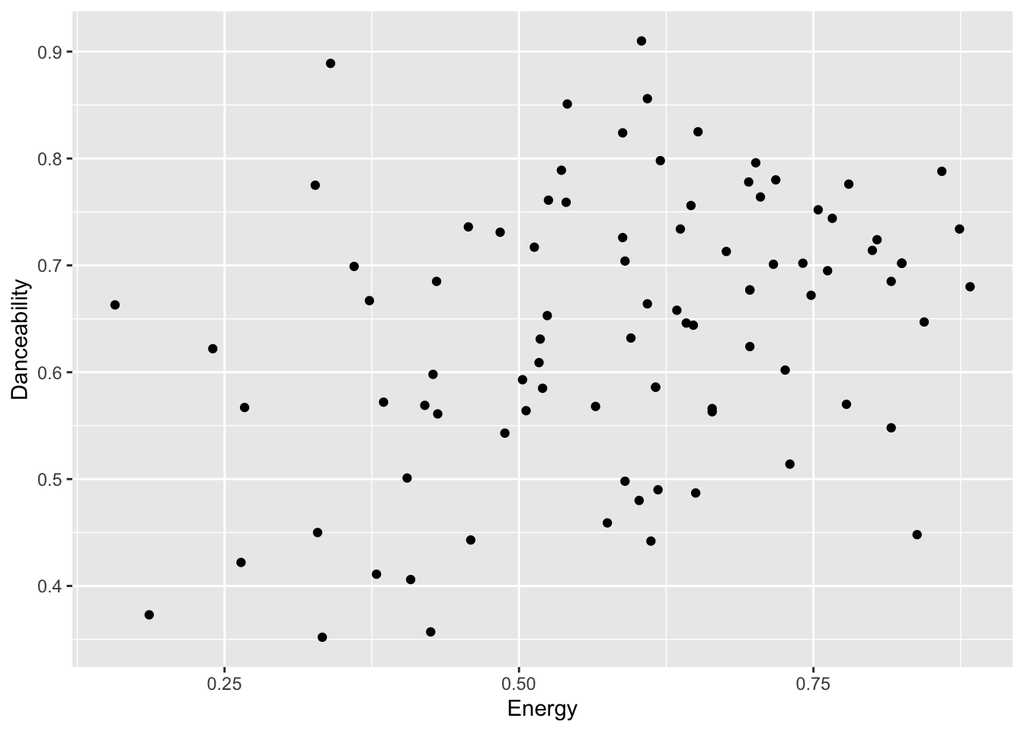

```r
# Create a scatter plot of energy vs. danceability
ggplot(data, aes(x = Energy, y = Danceability)) +
  geom_point() +
  labs(x = "Energy", y = "Danceability")
```

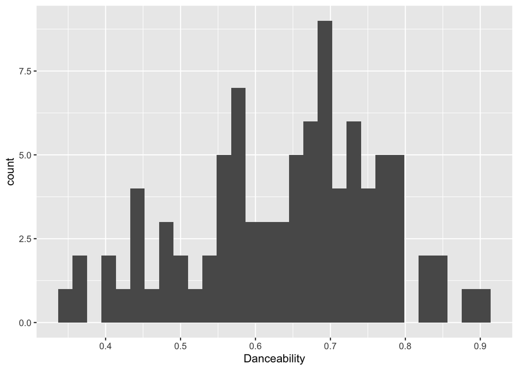

```r
# Create a histogram of danceability
ggplot(data, aes(x = Danceability)) +
  geom_histogram() +
  labs(x = "Danceability")
```

```r
# Create a correlation matrix of all variables
correlation <- cor(data$Energy, data$Danceability)
print(correlation)
```

```
## [1] 0.3336112
```

A correlation coefficient of 0.3336112 suggests a weak positive correlation between the two variables being analyzed. This means that there is a tendency for higher values of one variable to be associated with higher values of the other variable, but the relationship is not very strong. In this case, it indicates that there may be some relationship between the energy and danceability of songs, but it is not a strong or definitive relationship.

##### Load required packages

```r
library(tidyverse)
library(readr)
library(dplyr)
```

##### load the data into R

```r
pharm<- read_csv("pharma spend by country.csv")
```

```r
head(pharm)
```

```
## # A tibble: 6 × 7
##   LOCATION  TIME PC_HEALTHXP PC_GDP USD_CAP FLAG_CODES TOTAL_SPEND
##   <chr>    <dbl>       <dbl>  <dbl>   <dbl> <chr>            <dbl>
## 1 AUS       1971        16.0  0.727    35.7 <NA>              462.
## 2 AUS       1972        15.1  0.686    36.1 <NA>              475.
## 3 AUS       1973        15.1  0.681    39.9 <NA>              533.
## 4 AUS       1974        14.8  0.755    47.6 <NA>              653.
## 5 AUS       1975        11.8  0.682    47.6 <NA>              661.
## 6 AUS       1976        10.9  0.63     46.9 <NA>              658.
```

#### Tidying and transforming

groups the data by LOCATION using the group_by() function, and then summarizes the number of observations for each country using the summarize() function with the n() function

```r
pharm %>%
  group_by(LOCATION) %>%
  summarize(n_obs = n())
```

```
## # A tibble: 32 × 2
##    LOCATION n_obs
##    <chr>    <int>
##  1 AUS         44
##  2 AUT         26
##  3 BEL         41
##  4 CAN         45
##  5 CHE         31
##  6 CZE         26
##  7 DEU         45
##  8 DNK         36
##  9 ESP         32
## 10 EST         17
## # … with 22 more rows
```

```r
pharm%>%
  group_by(TIME) %>%
  summarize(n_obs = n())
```

```
## # A tibble: 47 × 2
##     TIME n_obs
##    <dbl> <int>
##  1  1970    11
##  2  1971    11
##  3  1972    11
##  4  1973    11
##  5  1974    11
##  6  1975    13
##  7  1976    13
##  8  1977    13
##  9  1978    13
## 10  1979    13
## # … with 37 more rows
```

```r
pharm%>%
  summarize(n_countries = n_distinct(LOCATION),
            n_years = n_distinct(TIME)) %>%
  bind_rows(pharm %>%
              group_by(LOCATION) %>%
              summarize(n_obs = n()) %>%
              summarize(n_countries = n_distinct(LOCATION),
                        n_obs = sum(n_obs)) %>%
              select(n_countries, n_obs)) %>%
  bind_rows(pharm %>%
              group_by(TIME) %>%
              summarize(n_obs = n()) %>%
              summarize(n_years = n_distinct(TIME),
                        n_obs = sum(n_obs)) %>%
              select(n_years, n_obs))
```

```
## # A tibble: 3 × 3
##   n_countries n_years n_obs
##         <int>   <int> <int>
## 1          32      47    NA
## 2          32      NA  1000
## 3          NA      47  1000
```

Some visualizations to explore the data

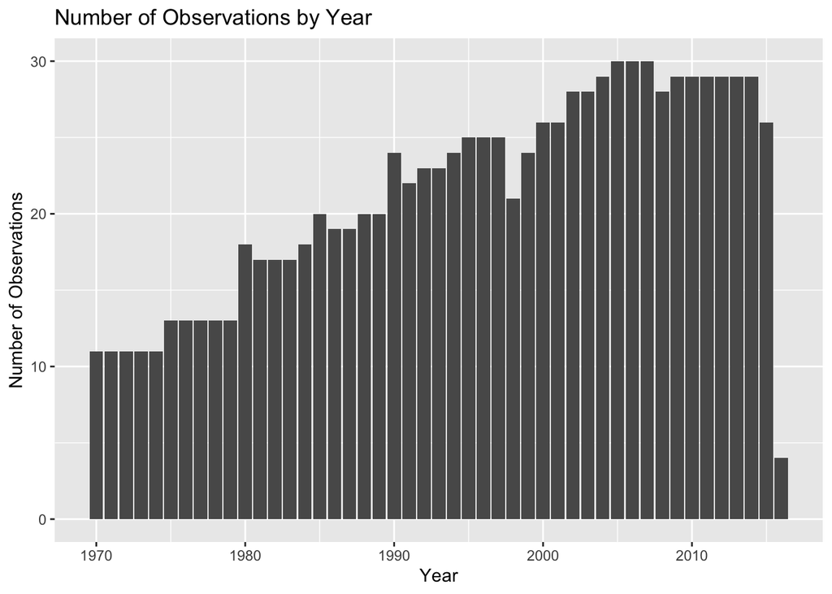

```r
pharm %>%
  group_by(TIME) %>%
  summarize(n_obs = n()) %>%
  ggplot(aes(x = TIME, y = n_obs)) +
  geom_bar(stat = "identity") +
  labs(x = "Year", y = "Number of Observations",
       title = "Number of Observations by Year")
```

[figure not shown]

```r
library(tidyverse)

for_label <- pharm %>%
  group_by(LOCATION) %>%
  summarize(year=max(TIME), totalspend=max(TOTAL_SPEND))

ggplot(data=pharm, aes(x=TIME, y=TOTAL_SPEND, group=LOCATION, color=LOCATION)) +
  geom_line(linewidth=1.2) +
  geom_text(data=for_label, aes(x=year, y=totalspend + 4000, label=LOCATION), size=3, color="black", fontface="bold") +
  scale_color_viridis_d() +
  labs(title="Pharmaceutical Spending by Country, 1971-2017",
       x="Year", y="Total Pharmaceutical Spending (USD billions)",
       color="Country") +
  theme_classic() +
  theme(plot.title = element_text(face="bold", size=18),
        axis.title = element_text(face="bold", size=14),
        axis.text = element_text(size=12),
        legend.position = "bottom",
        legend.title = element_text(face="bold", size=12),
        legend.text = element_text(size=10),
        panel.grid.major = element_blank(),
        panel.grid.minor = element_blank()) +
  annotate("text", x=1980, y=60000, label="USA has highest spending", size=5, color="black", fontface="bold") +
  annotate("segment", x=1980, xend=1990, y=60000, yend=60000, size=1.5, color="black", lineend="butt", arrow=arrow(length=unit(0.3,"cm"))) +
  annotate("text", x=1980, y=25000, label="Japan spends second most", size=5, color="black", fontface="bold") +
  annotate("segment", x=1980, xend=1990, y=25000, yend=25000, size=1.5, color="black", lineend="butt", arrow=arrow(length=unit(0.3,"cm"))) +
  annotate("text", x=1995, y=20000, label="Australia, Canada, France, and Germany have similar spending", size=5, color="black", fontface="bold") +
  annotate("segment", x=1995, xend=2005, y=20000, yend=20000, size=1.5, color="black", lineend="butt", arrow=arrow(length=unit(0.3,"cm")))
```

```r
library(dplyr)

summary_data <- pharm %>%
  group_by(LOCATION) %>%
  summarize(mean_spend = mean(TOTAL_SPEND),
            median_spend = median(TOTAL_SPEND),
            min_spend = min(TOTAL_SPEND),
            max_spend = max(TOTAL_SPEND),
            sd_spend = sd(TOTAL_SPEND))

head (summary_data)
```

```
## # A tibble: 6 × 6
##   LOCATION mean_spend median_spend min_spend max_spend sd_spend
##   <chr>         <dbl>        <dbl>     <dbl>     <dbl>    <dbl>
## 1 AUS           4786.        2765.      462.    14504.    4542.
## 2 AUT           3182.        3251.     1167.     5463.    1392.
## 3 BEL           3081.        2063.      405.     7655.    2425.
## 4 CAN           9892.        6974.      736.    27931.    9120.
## 5 CHE           3323.        2594.     1108.     8747.    2289.
## 6 CZE           3019.        3076.      994.     4659.    1159.
```